# Simplilearn Post Graduate Program - Data Science

**In Partnership With Purdue University**

Capstone Project Report - Healthcare PGP (Diabetes)

Organization: **Simplilearn - Purdue University**  
Batch: **PGP DS Mar 2022 COHORT 2**  
Course: **PC DS - Data Science Capstone**  
Project: **Healthcare PGP (Diabetes)**  
Programming Language: **Python**  
Submitted by: **Lavkush Singh**

## Problem Statement

**The project aims at building a model to accurately predict whether the patients in the dataset have diabetes or not.**

### Dataset Description

The datasets consists of several medical predictor variables and one target variable (Outcome). Predictor variables includes the number of pregnancies the patient has had, their BMI, insulin level, age, and more.

### Variables

- **Pregnancies** - Number of times pregnant
- **Glucose** - Plasma glucose concentration in an oral glucose tolerance test
- **BloodPressure** - Diastolic blood pressure (mm Hg)
- **SkinThickness** - Triceps skinfold thickness (mm)
- **Insulin** - Two hour serum insulin
- **BMI** - Body Mass Index
- **DiabetesPedigreeFunction** - Diabetes pedigree function
- **Age** - Age in years
- **Outcome** - Class variable (either 0 or 1). 268 of 768 values are 1, and the others are 0

### Analysis Tasks to be performed

**Task I: Data Exploration**

```
- Perform descriptive analysis. Understand the variables and their corresponding values. On the columns below, a value of zero does not make sense and thus indicates missing value:
    * Glucose
    * BloodPressure
    * SkinThickness
    * Insulin
    * BMI
- Visually explore these variables using histograms. Treat the missing values accordingly.
- There are integer and float data type variables in this dataset. Create a count (frequency) plot describing the data types and the count of variables.
- Check the balance of the data by plotting the count of outcomes by their value. Describe your findings and plan future course of action.
- Create scatter charts between the pair of variables to understand the relationships. Describe your findings.
- Perform correlation analysis. Visually explore it using a heat map.
```

**Task II: Data Modeling**

```
- Devise strategies for model building. It is important to decide the right validation framework. Express your thought process.
- Apply an appropriate classification algorithm to build a model.
- Compare various models with the results from KNN algorithm.
- Create a classification report by analyzing sensitivity, specificity, AUC (ROC curve), etc.
- Please be descriptive to explain what values of these parameter you have used.
```

**Task III: Tableau Report**

```
- Create a dashboard in tableau by choosing appropriate chart types and metrics useful for the business. The dashboard must entail the following:
- Pie chart to describe the diabetic or non-diabetic population
- Scatter charts between relevant variables to analyze the relationships
- Histogram or frequency charts to analyze the distribution of the data
- Heatmap of correlation analysis among the relevant variables
- Create bins of these age values: 20-25, 25-30, 30-35, etc. Analyze different variables for these age brackets using a bubble chart.
```

### Task I: Data Exploration

```python
# Importing required libraries

import numpy as np
import pandas as pd
import matplotlib.pyplot as plt
import seaborn as sns
import dabl
from sklearn.model_selection import train_test_split
from sklearn.preprocessing import MinMaxScaler
from sklearn.decomposition import PCA
from sklearn.linear_model import LogisticRegression
from sklearn.svm import SVC
from sklearn.tree import DecisionTreeClassifier
from sklearn.ensemble import RandomForestClassifier
import xgboost as xgb
from sklearn.neighbors import KNeighborsClassifier
from sklearn.model_selection import GridSearchCV, KFold, cross_val_score
from sklearn.metrics import accuracy_score, classification_report, confusion_matrix, ConfusionMatrixDisplay
from plot_metric.functions import BinaryClassification
```

```python
# settings to display all columns

pd.set_option("display.max_columns", None)
pd.options.display.max_rows = None
```

```python
# reading the data

diabetes_data = pd.read_csv('Datasets/health care diabetes.csv')
```

```python
diabetes_data.head() # viewing first few observations of train dataset
```

|  | Pregnancies | Glucose | BloodPressure | SkinThickness | Insulin | BMI | DiabetesPedigreeFunction | Age | Outcome |
| --- | --- | --- | --- | --- | --- | --- | --- | --- | --- |
| 0 | 6 | 148 | 72 | 35 | 0 | 33.6 | 0.627 | 50 | 1 |
| 1 | 1 | 85 | 66 | 29 | 0 | 26.6 | 0.351 | 31 | 0 |
| 2 | 8 | 183 | 64 | 0 | 0 | 23.3 | 0.672 | 32 | 1 |
| 3 | 1 | 89 | 66 | 23 | 94 | 28.1 | 0.167 | 21 | 0 |
| 4 | 0 | 137 | 40 | 35 | 168 | 43.1 | 2.288 | 33 | 1 |

#### Task I (a): Perform descriptive analysis. (Preliminary Data Inspection and Data Cleaning)

```python
diabetes_data.shape # checking rows and cols of the train dataset
```

```
(768, 9)
```

```python
diabetes_data.info()  # understanding column wise datatype and null values
```

```
<class 'pandas.core.frame.DataFrame'>
RangeIndex: 768 entries, 0 to 767
Data columns (total 9 columns):
 #   Column                    Non-Null Count  Dtype
---  ------                    --------------  -----
 0   Pregnancies               768 non-null    int64
 1   Glucose                   768 non-null    int64
 2   BloodPressure             768 non-null    int64
 3   SkinThickness             768 non-null    int64
 4   Insulin                   768 non-null    int64
 5   BMI                       768 non-null    float64
 6   DiabetesPedigreeFunction  768 non-null    float64
 7   Age                       768 non-null    int64
 8   Outcome                   768 non-null    int64
dtypes: float64(2), int64(7)
memory usage: 54.1 KB
```

```python
diabetes_data.describe() # descriptive statistics of numerical columns
```

|  | Pregnancies | Glucose | BloodPressure | SkinThickness | Insulin | BMI | DiabetesPedigreeFunction | Age | Outcome |
| --- | --- | --- | --- | --- | --- | --- | --- | --- | --- |
| count | 768.000000 | 768.000000 | 768.000000 | 768.000000 | 768.000000 | 768.000000 | 768.000000 | 768.000000 | 768.000000 |
| mean | 3.845052 | 120.894531 | 69.105469 | 20.536458 | 79.799479 | 31.992578 | 0.471876 | 33.240885 | 0.348958 |
| std | 3.369578 | 31.972618 | 19.355807 | 15.952218 | 115.244002 | 7.884160 | 0.331329 | 11.760232 | 0.476951 |
| min | 0.000000 | 0.000000 | 0.000000 | 0.000000 | 0.000000 | 0.000000 | 0.078000 | 21.000000 | 0.000000 |
| 25% | 1.000000 | 99.000000 | 62.000000 | 0.000000 | 0.000000 | 27.300000 | 0.243750 | 24.000000 | 0.000000 |
| 50% | 3.000000 | 117.000000 | 72.000000 | 23.000000 | 30.500000 | 32.000000 | 0.372500 | 29.000000 | 0.000000 |
| 75% | 6.000000 | 140.250000 | 80.000000 | 32.000000 | 127.250000 | 36.600000 | 0.626250 | 41.000000 | 1.000000 |
| max | 17.000000 | 199.000000 | 122.000000 | 99.000000 | 846.000000 | 67.100000 | 2.420000 | 81.000000 | 1.000000 |

Visualizing the distribution of columns (independent variables) via KDE Plot

```python
# converting columns into array to traverse through it and plotting graph as sub-plots

arr_cols = np.array(diabetes_data.columns[:4]).reshape(2,2)
arr_cols
```

```
array([['Pregnancies', 'Glucose'],
       ['BloodPressure', 'SkinThickness']], dtype=object)
```

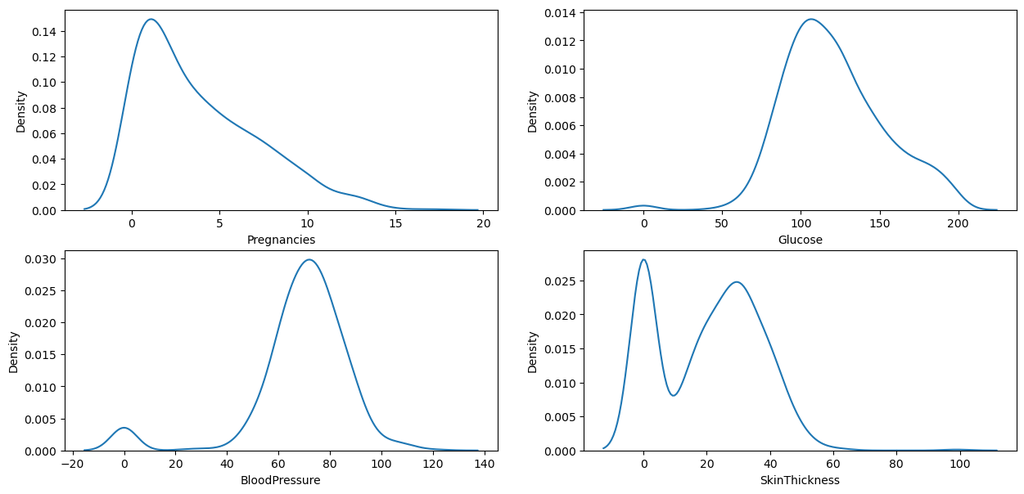

```python
# plotting KDE plot to view how the data is distributed

fig, axes = plt.subplots(2, 2, figsize=(15, 7))
for i in range(2):
    for j in range(2):
        sns.kdeplot(ax=axes[i, j], data = diabetes_data, x = arr_cols[i,j])
```

```python
# converting columns into array to traverse through it and plotting graph as sub-plots

arr_cols = np.array(diabetes_data.columns[4:-1]).reshape(2,2)
arr_cols
```

```
array([['Insulin', 'BMI'],
       ['DiabetesPedigreeFunction', 'Age']], dtype=object)
```

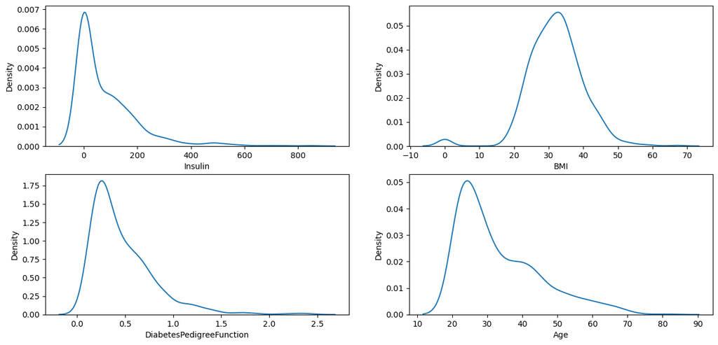

```python
# plotting KDE plot to view how the data is distributed

fig, axes = plt.subplots(2, 2, figsize=(15, 7))
for i in range(2):
    for j in range(2):
        sns.kdeplot(ax=axes[i, j], data = diabetes_data, x = arr_cols[i,j])
```